# TITANIC EDA

## Adeline Carol Fernandes

```python
import numpy as np
import pandas as pd
import matplotlib.pyplot as plt
%matplotlib inline
import seaborn as sns
```

```python
titanic=pd.read_csv('TITANIC.csv')
```

```python
titanic.head()
```

|  | PassengerId | Survived | Pclass | Name | Sex | Age | SibSp | Parch | Ticket | Fare | Cabin | Embarked |
| --- | --- | --- | --- | --- | --- | --- | --- | --- | --- | --- | --- | --- |
| 0 | 1 | 0 | 3 | Braund, Mr. Owen Harris | male | 22.0 | 1 | 0 | A/5 21171 | 7.2500 | NaN | S |
| 1 | 2 | 1 | 1 | Cumings, Mrs. John Bradley (Florence Briggs Th... | female | 38.0 | 1 | 0 | PC 17599 | 71.2833 | C85 | C |
| 2 | 3 | 1 | 3 | Heikkinen, Miss. Laina | female | 26.0 | 0 | 0 | STON/O2. 3101282 | 7.9250 | NaN | S |
| 3 | 4 | 1 | 1 | Futrelle, Mrs. Jacques Heath (Lily May Peel) | female | 35.0 | 1 | 0 | 113803 | 53.1000 | C123 | S |
| 4 | 5 | 0 | 3 | Allen, Mr. William Henry | male | 35.0 | 0 | 0 | 373450 | 8.0500 | NaN | S |

```python
titanic.tail()
```

|  | PassengerId | Survived | Pclass | Name | Sex | Age | SibSp | Parch | Ticket | Fare | Cabin | Embarked |
| --- | --- | --- | --- | --- | --- | --- | --- | --- | --- | --- | --- | --- |
| 886 | 887 | 0 | 2 | Montvila, Rev. Juozas | male | 27.0 | 0 | 0 | 211536 | 13.00 | NaN | S |
| 887 | 888 | 1 | 1 | Graham, Miss. Margaret Edith | female | 19.0 | 0 | 0 | 112053 | 30.00 | B42 | S |
| 888 | 889 | 0 | 3 | Johnston, Miss. Catherine Helen "Carrie" | female | NaN | 1 | 2 | W./C. 6607 | 23.45 | NaN | S |
| 889 | 890 | 1 | 1 | Behr, Mr. Karl Howell | male | 26.0 | 0 | 0 | 111369 | 30.00 | C148 | C |
| 890 | 891 | 0 | 3 | Dooley, Mr. Patrick | male | 32.0 | 0 | 0 | 370376 | 7.75 | NaN | Q |

## Variable Identification

### Dependent Variable :Survived

### Independent Variable:

1.Pclass

2.Sex

3.Age

4.SibSp

5.Parch

6.Fare

7..Embarked

## Data Types

### String:

Name

Sex

Ticket

Cabin

Embarked

### Numeric:

PassengerId

Survived

Pclass

SibSp

Parch

Age

Fare

### Variable Category

#### Categorical:

1.Pclass

2.Sex

3.Survived

4.Embarked

### Continous:

1.Age

2.Fare

### Discreet:

1.SibSp

2.Parch

```python
titanic.info()
```

```
<class 'pandas.core.frame.DataFrame'>
RangeIndex: 891 entries, 0 to 890
Data columns (total 12 columns):
 #   Column       Non-Null Count  Dtype
---  ------       --------------  -----
 0   PassengerId  891 non-null    int64
 1   Survived     891 non-null    int64
 2   Pclass       891 non-null    int64
 3   Name         891 non-null    object
 4   Sex          891 non-null    object
 5   Age          714 non-null    float64
 6   SibSp        891 non-null    int64
 7   Parch        891 non-null    int64
 8   Ticket       891 non-null    object
 9   Fare         891 non-null    float64
 10  Cabin        204 non-null    object
 11  Embarked     889 non-null    object
dtypes: float64(2), int64(5), object(5)
memory usage: 66.2+ KB
```

```python
titanic.describe()
```

|  | PassengerId | Survived | Pclass | Age | SibSp | Parch | Fare |
| --- | --- | --- | --- | --- | --- | --- | --- |
| count | 891.000000 | 891.000000 | 891.000000 | 714.000000 | 891.000000 | 891.000000 | 891.000000 |
| mean | 446.000000 | 0.383838 | 2.308642 | 29.699118 | 0.523008 | 0.381594 | 32.204208 |
| std | 257.353842 | 0.486592 | 0.836071 | 14.526497 | 1.102743 | 0.806057 | 49.693429 |
| min | 1.000000 | 0.000000 | 1.000000 | 0.420000 | 0.000000 | 0.000000 | 0.000000 |
| 25% | 223.500000 | 0.000000 | 2.000000 | 20.125000 | 0.000000 | 0.000000 | 7.910400 |
| 50% | 446.000000 | 0.000000 | 3.000000 | 28.000000 | 0.000000 | 0.000000 | 14.454200 |
| 75% | 668.500000 | 1.000000 | 3.000000 | 38.000000 | 1.000000 | 0.000000 | 31.000000 |
| max | 891.000000 | 1.000000 | 3.000000 | 80.000000 | 8.000000 | 6.000000 | 512.329200 |

```python
titanic.describe(include='all')
```

|  | PassengerId | Survived | Pclass | Name | Sex | Age | SibSp | Parch | Ticket | Fare | Cabin | Embarked |
| --- | --- | --- | --- | --- | --- | --- | --- | --- | --- | --- | --- | --- |
| count | 891.000000 | 891.000000 | 891.000000 | 891 | 891 | 714.000000 | 891.000000 | 891.000000 | 891 | 891.000000 | 204 | 889 |
| unique | NaN | NaN | NaN | 891 | 2 | NaN | NaN | NaN | 681 | NaN | 147 | 3 |
| top | NaN | NaN | NaN | Sundman, Mr. Johan Julian | male | NaN | NaN | NaN | CA. 2343 | NaN | B96 B98 | S |
| freq | NaN | NaN | NaN | 1 | 577 | NaN | NaN | NaN | 7 | NaN | 4 | 644 |
| mean | 446.000000 | 0.383838 | 2.308642 | NaN | NaN | 29.699118 | 0.523008 | 0.381594 | NaN | 32.204208 | NaN | NaN |
| std | 257.353842 | 0.486592 | 0.836071 | NaN | NaN | 14.526497 | 1.102743 | 0.806057 | NaN | 49.693429 | NaN | NaN |
| min | 1.000000 | 0.000000 | 1.000000 | NaN | NaN | 0.420000 | 0.000000 | 0.000000 | NaN | 0.000000 | NaN | NaN |
| 25% | 223.500000 | 0.000000 | 2.000000 | NaN | NaN | 20.125000 | 0.000000 | 0.000000 | NaN | 7.910400 | NaN | NaN |
| 50% | 446.000000 | 0.000000 | 3.000000 | NaN | NaN | 28.000000 | 0.000000 | 0.000000 | NaN | 14.454200 | NaN | NaN |
| 75% | 668.500000 | 1.000000 | 3.000000 | NaN | NaN | 38.000000 | 1.000000 | 0.000000 | NaN | 31.000000 | NaN | NaN |
| max | 891.000000 | 1.000000 | 3.000000 | NaN | NaN | 80.000000 | 8.000000 | 6.000000 | NaN | 512.329200 | NaN | NaN |

# Univariate Analysis

### Categorical

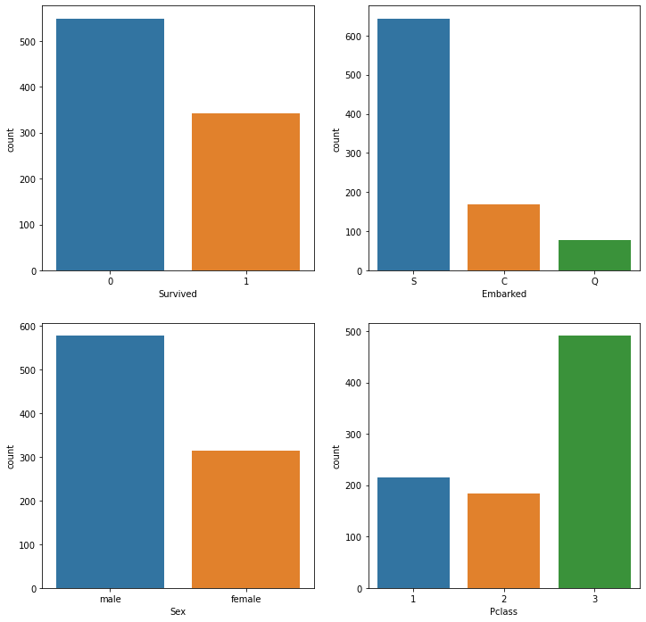

```python
plt.figure(figsize=(12,12))
plt.subplot(2,2,1)
sns.countplot(x='Survived',data=titanic)
plt.subplot(2,2,2)
sns.countplot(x='Embarked',data=titanic)
plt.subplot(2,2,3)
sns.countplot(x='Sex',data=titanic)
plt.subplot(2,2,4)
sns.countplot(x='Pclass',data=titanic)
```

#### The titanic had more more male passengers onboard , most of the passengers chose Pclass-3 , and unfortunately the survival rate of the passengers is less.

### Continous Variables

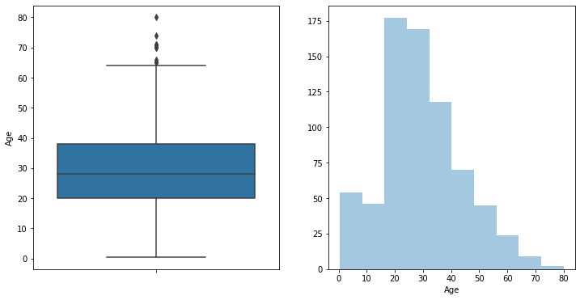

```python
plt.figure(figsize=(12,6))
plt.subplot(1,2,1)
sns.boxplot(y='Age',data=titanic)
plt.subplot(1,2,2)
sns.distplot(titanic['Age'],bins=10,kde=False)
```

outliers are observed on age and that most of the people are between 20 to 40 years of age.

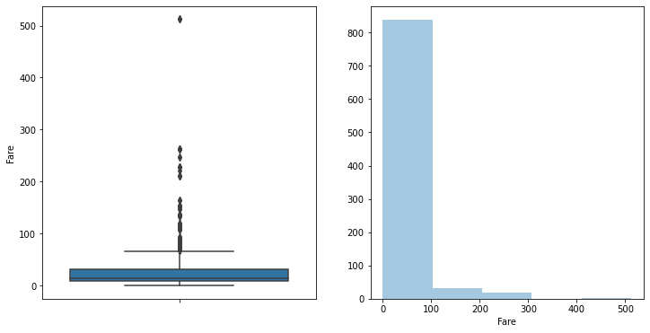

```python
plt.figure(figsize=(12,6))
plt.subplot(1,2,1)
sns.boxplot(y='Fare',data=titanic)
plt.subplot(1,2,2)
sns.distplot(titanic['Fare'],bins=5,kde=False)
```

Outliers are observed on fares.

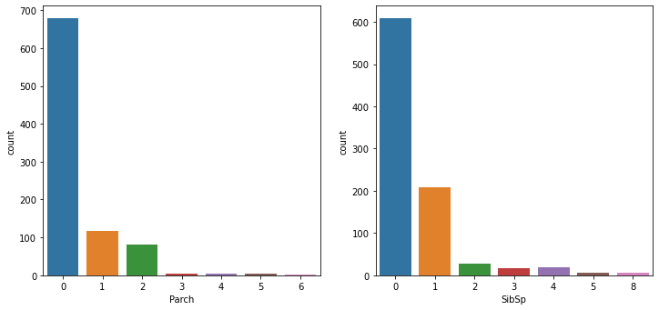

```python
plt.figure(figsize=(12,12))
plt.subplot(2,2,1)
sns.countplot(x='Parch',data=titanic)
plt.subplot(2,2,2)
sns.countplot(x='SibSp',data=titanic)
```

## Bivariate Analysis

#### Continuous & continuous

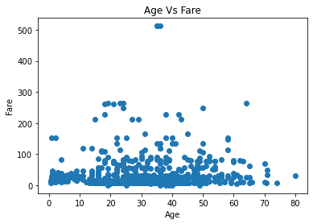

```python
plt.scatter(titanic['Age'],titanic['Fare'])
plt.title('Age Vs Fare')
plt.xlabel('Age')
plt.ylabel('Fare')
```

No strong correlation is observed.

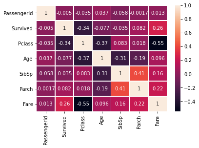

```python
sns.heatmap(titanic.corr(),annot=True,linewidth=0.5)
```

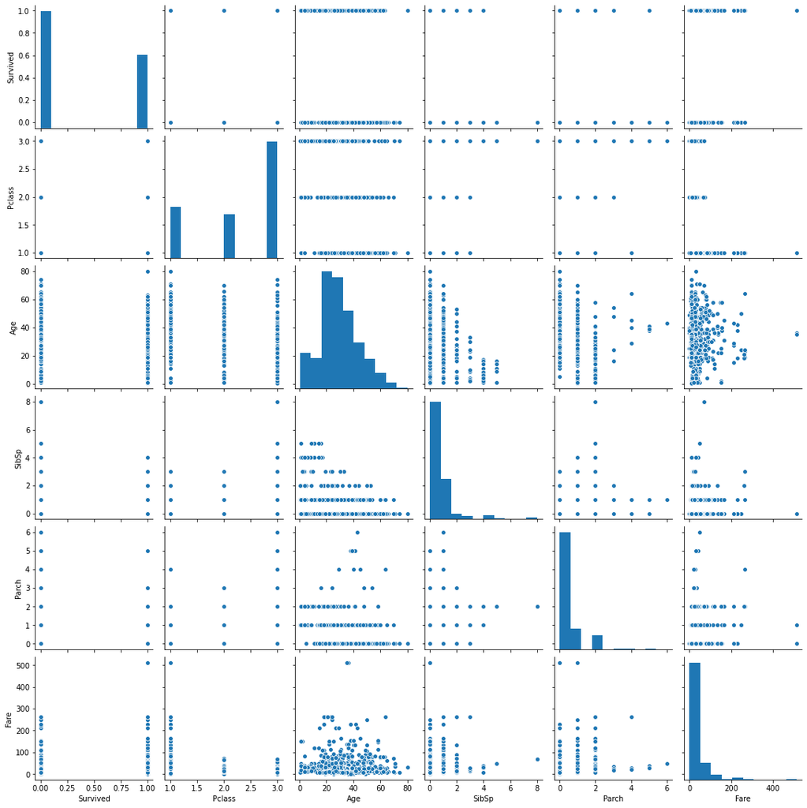

```python
titan=titanic.iloc[:,1:]
sns.pairplot(titan)
```

### Categorical and Categorical

```python
counts=titanic.groupby(['Sex','Survived'])
counts.size()
```

```
Sex     Survived
female  0            81
        1           233
male    0           468
        1           109
dtype: int64
```

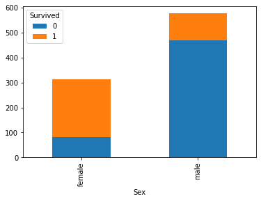

```python
pd.crosstab(titanic['Sex'],titanic['Survived']).plot(kind='bar',stacked=True)
```

### More female passengers survived than male

```python
counts=titanic.groupby(['Pclass','Survived'])
counts.size()
```

```
Pclass  Survived
1       0            80
        1           136
2       0            97
        1            87
3       0           372
        1           119
dtype: int64
```

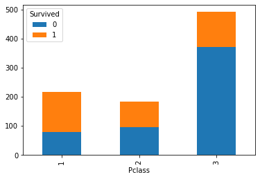

```python
pd.crosstab(titanic['Pclass'],titanic['Survived']).plot(kind='bar',stacked=True)
```

#### highest survivors are of Pclass 1 and highest casualties are in Pclass 3

```python
counts=titanic.groupby(['Embarked','Survived'])
```

```python
counts.size()
```

```
Embarked  Survived
C         0            75
          1            93
Q         0            47
          1            30
S         0           427
          1           217
dtype: int64
```

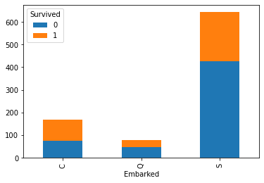

```python
pd.crosstab(titanic['Embarked'],titanic['Survived']).plot(kind='bar',stacked=True)
```

```python
counts=titanic.groupby(['SibSp','Survived'])
counts.size()
```

```
SibSp  Survived
0      0           398
       1           210
1      0            97
       1           112
2      0            15
       1            13
3      0            12
       1             4
4      0            15
       1             3
5      0             5
8      0             7
dtype: int64
```

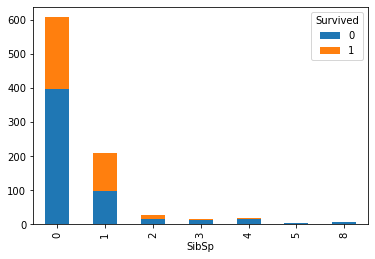

```python
pd.crosstab(titanic['SibSp'],titanic['Survived']).plot(kind='bar',stacked=True)
```

```python
counts=titanic.groupby(['Parch','Survived'])
counts.size()
```

```
Parch  Survived
0      0           445
       1           233
1      0            53
       1            65
2      0            40
       1            40
3      0             2
       1             3
4      0             4
5      0             4
       1             1
6      0             1
dtype: int64
```

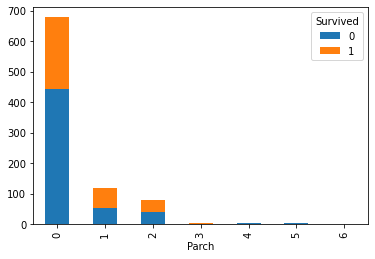

```python
pd.crosstab(titanic['Parch'],titanic['Survived']).plot(kind='bar',stacked=True)
```

## Missing Values Treatment

```python
titanic.isnull()
```

|  | PassengerId | Survived | Pclass | Name | Sex | Age | SibSp | Parch | Ticket | Fare | Cabin | Embarked |
| --- | --- | --- | --- | --- | --- | --- | --- | --- | --- | --- | --- | --- |
| 0 | False | False | False | False | False | False | False | False | False | False | True | False |
| 1 | False | False | False | False | False | False | False | False | False | False | False | False |
| 2 | False | False | False | False | False | False | False | False | False | False | True | False |
| 3 | False | False | False | False | False | False | False | False | False | False | False | False |
| 4 | False | False | False | False | False | False | False | False | False | False | True | False |
| ... | ... | ... | ... | ... | ... | ... | ... | ... | ... | ... | ... | ... |
| 886 | False | False | False | False | False | False | False | False | False | False | True | False |
| 887 | False | False | False | False | False | False | False | False | False | False | False | False |
| 888 | False | False | False | False | False | True | False | False | False | False | True | False |
| 889 | False | False | False | False | False | False | False | False | False | False | False | False |
| 890 | False | False | False | False | False | False | False | False | False | False | True | False |

891 rows × 12 columns

```python
titanic.isnull().values.any()
```

```
True
```

```python
titanic.info()
```

```
<class 'pandas.core.frame.DataFrame'>
RangeIndex: 891 entries, 0 to 890
Data columns (total 12 columns):
 #   Column       Non-Null Count  Dtype
---  ------       --------------  -----
 0   PassengerId  891 non-null    int64
 1   Survived     891 non-null    int64
 2   Pclass       891 non-null    int64
 3   Name         891 non-null    object
 4   Sex          891 non-null    object
 5   Age          714 non-null    float64
 6   SibSp        891 non-null    int64
 7   Parch        891 non-null    int64
 8   Ticket       891 non-null    object
 9   Fare         891 non-null    float64
 10  Cabin        204 non-null    object
 11  Embarked     889 non-null    object
dtypes: float64(2), int64(5), object(5)
memory usage: 66.2+ KB
```

Age,Cabin,Embarked have missing values

```python
titanic.describe()
```

|  | PassengerId | Survived | Pclass | Age | SibSp | Parch | Fare |
| --- | --- | --- | --- | --- | --- | --- | --- |
| count | 891.000000 | 891.000000 | 891.000000 | 714.000000 | 891.000000 | 891.000000 | 891.000000 |
| mean | 446.000000 | 0.383838 | 2.308642 | 29.699118 | 0.523008 | 0.381594 | 32.204208 |
| std | 257.353842 | 0.486592 | 0.836071 | 14.526497 | 1.102743 | 0.806057 | 49.693429 |
| min | 1.000000 | 0.000000 | 1.000000 | 0.420000 | 0.000000 | 0.000000 | 0.000000 |
| 25% | 223.500000 | 0.000000 | 2.000000 | 20.125000 | 0.000000 | 0.000000 | 7.910400 |
| 50% | 446.000000 | 0.000000 | 3.000000 | 28.000000 | 0.000000 | 0.000000 | 14.454200 |
| 75% | 668.500000 | 1.000000 | 3.000000 | 38.000000 | 1.000000 | 0.000000 | 31.000000 |
| max | 891.000000 | 1.000000 | 3.000000 | 80.000000 | 8.000000 | 6.000000 | 512.329200 |

```python
titanic.isnull().sum()
```

```
PassengerId      0
Survived         0
Pclass           0
Name             0
Sex              0
Age            177
SibSp            0
Parch            0
Ticket           0
Fare             0
Cabin          687
Embarked         2
dtype: int64
```

##### Since about 77% of values in Cabin are null values ,Cabin variable is deleted.

```python
del titanic['Cabin']
```

```python
titanic.head()
```

|  | PassengerId | Survived | Pclass | Name | Sex | Age | SibSp | Parch | Ticket | Fare | Embarked |
| --- | --- | --- | --- | --- | --- | --- | --- | --- | --- | --- | --- |
| 0 | 1 | 0 | 3 | Braund, Mr. Owen Harris | male | 22.0 | 1 | 0 | A/5 21171 | 7.2500 | S |
| 1 | 2 | 1 | 1 | Cumings, Mrs. John Bradley (Florence Briggs Th... | female | 38.0 | 1 | 0 | PC 17599 | 71.2833 | C |
| 2 | 3 | 1 | 3 | Heikkinen, Miss. Laina | female | 26.0 | 0 | 0 | STON/O2. 3101282 | 7.9250 | S |
| 3 | 4 | 1 | 1 | Futrelle, Mrs. Jacques Heath (Lily May Peel) | female | 35.0 | 1 | 0 | 113803 | 53.1000 | S |
| 4 | 5 | 0 | 3 | Allen, Mr. William Henry | male | 35.0 | 0 | 0 | 373450 | 8.0500 | S |

#### Since Embarked variable is categorical we replace the missing values with mode

```python
titanic['Embarked'].mode()
```

```
0    S
dtype: object
```

```python
titanic['Embarked'].fillna(value='S',inplace=True)
```

```python
titanic.isnull().sum()
```

```
PassengerId      0
Survived         0
Pclass           0
Name             0
Sex              0
Age            177
SibSp            0
Parch            0
Ticket           0
Fare             0
Embarked         0
dtype: int64
```

### Missing values in Age

```
array([[<matplotlib.axes._subplots.AxesSubplot object at 0x11898EF0>]],
      dtype=object)
```

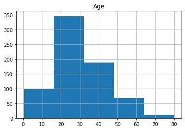

```python
titanic.hist(column=['Age'], bins=5)
```

```python
titanic['Age'].skew(axis=0)
```

```
0.38910778230082704
```

#### We observe that Age has a normal distribution,therefore replace all null values in age with median.

```python
titanic['Age']=titanic['Age'].fillna(value=titanic['Age'].median())
```

```python
titanic.isnull().sum()
```

```
PassengerId    0
Survived       0
Pclass         0
Name           0
Sex            0
Age            0
SibSp          0
Parch          0
Ticket         0
Fare           0
Embarked       0
dtype: int64
```

## Outliers

```python
del titanic['PassengerId']
```

```python
del titanic['Name']
```

```python
del titanic['Ticket']
```

```python
titanic.head()
```

|  | Survived | Pclass | Sex | Age | SibSp | Parch | Fare | Embarked |
| --- | --- | --- | --- | --- | --- | --- | --- | --- |
| 0 | 0 | 3 | male | 22.0 | 1 | 0 | 7.2500 | S |
| 1 | 1 | 1 | female | 38.0 | 1 | 0 | 71.2833 | C |
| 2 | 1 | 3 | female | 26.0 | 0 | 0 | 7.9250 | S |
| 3 | 1 | 1 | female | 35.0 | 1 | 0 | 53.1000 | S |
| 4 | 0 | 3 | male | 35.0 | 0 | 0 | 8.0500 | S |

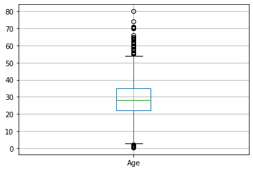

```python
titanic.boxplot(column=['Age'])
```

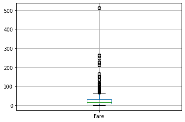

```python
titanic.boxplot(column=['Fare'])
```

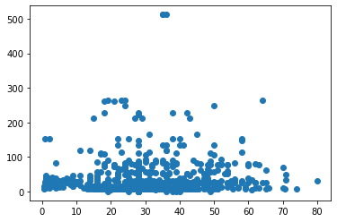

```python
plt.scatter(titanic['Age'],titanic['Fare'])
```

## Treating age outliers

```python
titanic['Age'].describe()
```

```
count    891.000000
mean      29.361582
std       13.019697
min        0.420000
25%       22.000000
50%       28.000000
75%       35.000000
max       80.000000
Name: Age, dtype: float64
```

```python
IQR = titanic['Age'].quantile(0.75)-titanic['Age'].quantile(0.25)
print(IQR)
```

```
13.0
```

```python
Upper_OutlierLimit = titanic['Age'].quantile(0.75) + 1.5*IQR
Lower_OutlierLimit = titanic['Age'].quantile(0.25) - 1.5*IQR
print(Upper_OutlierLimit)
print(Lower_OutlierLimit)
```

```
54.5
2.5
```

```python
outliervalues_age=titanic[(titanic['Age']>=Upper_OutlierLimit)|(titanic['Age']<=Lower_OutlierLimit)]
```

```python
outliervalues_age
```

|  | Survived | Pclass | Sex | Age | SibSp | Parch | Fare | Embarked |
| --- | --- | --- | --- | --- | --- | --- | --- | --- |
| 7 | 0 | 3 | male | 2.00 | 3 | 1 | 21.0750 | S |
| 11 | 1 | 1 | female | 58.00 | 0 | 0 | 26.5500 | S |
| 15 | 1 | 2 | female | 55.00 | 0 | 0 | 16.0000 | S |
| 16 | 0 | 3 | male | 2.00 | 4 | 1 | 29.1250 | Q |
| 33 | 0 | 2 | male | 66.00 | 0 | 0 | 10.5000 | S |
| ... | ... | ... | ... | ... | ... | ... | ... | ... |
| 827 | 1 | 2 | male | 1.00 | 0 | 2 | 37.0042 | C |
| 829 | 1 | 1 | female | 62.00 | 0 | 0 | 80.0000 | S |
| 831 | 1 | 2 | male | 0.83 | 1 | 1 | 18.7500 | S |
| 851 | 0 | 3 | male | 74.00 | 0 | 0 | 7.7750 | S |
| 879 | 1 | 1 | female | 56.00 | 0 | 1 | 83.1583 | C |

66 rows × 8 columns

```python
titanic['Age'][(titanic['Age']>=Upper_OutlierLimit)]=titanic['Age'].quantile(0.95)
```

[output not shown]

```python
titanic['Age'][(titanic['Age']<=Lower_OutlierLimit)]=titanic['Age'].quantile(0.05)
```

[output not shown]

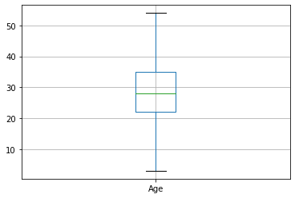

```python
titanic.boxplot(column='Age')
```

## Fare outliers

```python
titanic['Fare'].describe()
```

```
count    891.000000
mean      32.204208
std       49.693429
min        0.000000
25%        7.910400
50%       14.454200
75%       31.000000
max      512.329200
Name: Fare, dtype: float64
```

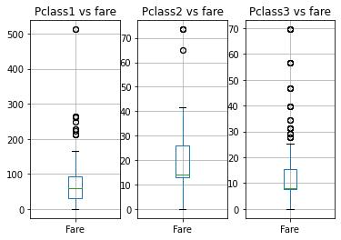

```python
pclass1=titanic[titanic['Pclass']==1]
pclass2=titanic[titanic['Pclass']==2]
pclass3=titanic[titanic['Pclass']==3]
plt.subplot(1,3,1)
pclass1.boxplot(column=['Fare'])
plt.title('Pclass1 vs fare')

plt.subplot(1,3,2)
pclass2.boxplot(column=['Fare'])
plt.title('Pclass2 vs fare')
plt.subplot(1,3,3)
pclass3.boxplot(column=['Fare'])
plt.title('Pclass3 vs fare')
```

Treating outliers of Pclass 1

```python
iqrp1=pclass1['Fare'].quantile(0.75)-pclass1['Fare'].quantile(0.25)
print(iqrp1)
```

```
62.57605
```

```python
Upper_OutlierLimit1 = pclass1['Fare'].quantile(0.75) + 1.5*iqrp1
Lower_OutlierLimit1 = pclass1['Fare'].quantile(0.25) - 1.5*iqrp1
print(Upper_OutlierLimit1)
print(Lower_OutlierLimit1)
```

```
187.364075
-62.940125
```

```python
OutlierValues1 = pclass1[(pclass1['Fare']>=Upper_OutlierLimit1) | (pclass1['Fare']<=Lower_OutlierLimit1)]
OutlierValues1
```

|  | Survived | Pclass | Sex | Age | SibSp | Parch | Fare | Embarked |
| --- | --- | --- | --- | --- | --- | --- | --- | --- |
| 27 | 0 | 1 | male | 19.0 | 3 | 2 | 263.0000 | S |
| 88 | 1 | 1 | female | 23.0 | 3 | 2 | 263.0000 | S |
| 118 | 0 | 1 | male | 24.0 | 0 | 1 | 247.5208 | C |
| 258 | 1 | 1 | female | 35.0 | 0 | 0 | 512.3292 | C |
| 299 | 1 | 1 | female | 50.0 | 0 | 1 | 247.5208 | C |
| 311 | 1 | 1 | female | 18.0 | 2 | 2 | 262.3750 | C |
| 341 | 1 | 1 | female | 24.0 | 3 | 2 | 263.0000 | S |
| 377 | 0 | 1 | male | 27.0 | 0 | 2 | 211.5000 | C |
| 380 | 1 | 1 | female | 42.0 | 0 | 0 | 227.5250 | C |
| 438 | 0 | 1 | male | 54.0 | 1 | 4 | 263.0000 | S |
| 527 | 0 | 1 | male | 28.0 | 0 | 0 | 221.7792 | S |
| 557 | 0 | 1 | male | 28.0 | 0 | 0 | 227.5250 | C |
| 679 | 1 | 1 | male | 36.0 | 0 | 1 | 512.3292 | C |
| 689 | 1 | 1 | female | 15.0 | 0 | 1 | 211.3375 | S |
| 700 | 1 | 1 | female | 18.0 | 1 | 0 | 227.5250 | C |
| 716 | 1 | 1 | female | 38.0 | 0 | 0 | 227.5250 | C |
| 730 | 1 | 1 | female | 29.0 | 0 | 0 | 211.3375 | S |
| 737 | 1 | 1 | male | 35.0 | 0 | 0 | 512.3292 | C |
| 742 | 1 | 1 | female | 21.0 | 2 | 2 | 262.3750 | C |
| 779 | 1 | 1 | female | 43.0 | 0 | 1 | 211.3375 | S |

```python
pclass1[(pclass1['Fare']>=Upper_OutlierLimit1)].info()
```

```
<class 'pandas.core.frame.DataFrame'>
Int64Index: 20 entries, 27 to 779
Data columns (total 8 columns):
 #   Column    Non-Null Count  Dtype
---  ------    --------------  -----
 0   Survived  20 non-null     int64
 1   Pclass    20 non-null     int64
 2   Sex       20 non-null     object
 3   Age       20 non-null     float64
 4   SibSp     20 non-null     int64
 5   Parch     20 non-null     int64
 6   Fare      20 non-null     float64
 7   Embarked  20 non-null     object
dtypes: float64(2), int64(4), object(2)
memory usage: 1.2+ KB
```

We have 20 outliers in fare of passengers who travel in Pclass-1

```python
pclass1['Fare'][(pclass1['Fare']>Upper_OutlierLimit1)]=pclass1['Fare'].quantile(0.90)
```

[output not shown]

```python
pclass1[pclass1['Fare']>Upper_OutlierLimit1]
```

|  | Survived | Pclass | Sex | Age | SibSp | Parch | Fare | Embarked |
| --- | --- | --- | --- | --- | --- | --- | --- | --- |

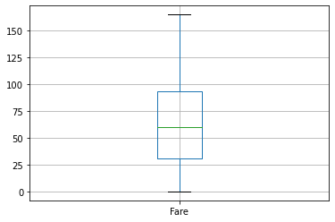

```python
pclass1.boxplot(column=['Fare'])
```

Pclass1 is capped to 90%

### Pclass 2

```python
iqrp2=pclass2['Fare'].quantile(0.75)-pclass2['Fare'].quantile(0.25)
print(iqrp2)
```

```
13.0
```

```python
Upper_OutlierLimit2 = pclass2['Fare'].quantile(0.75) + 1.5*iqrp2
Lower_OutlierLimit2 = pclass2['Fare'].quantile(0.25) - 1.5*iqrp2
print(Upper_OutlierLimit2)
print(Lower_OutlierLimit2)
```

```
45.5
-6.5
```

```python
OutlierValues2 = pclass2[(pclass2['Fare']>=Upper_OutlierLimit2) | (pclass2['Fare']<=Lower_OutlierLimit2)]
OutlierValues2
```

|  | Survived | Pclass | Sex | Age | SibSp | Parch | Fare | Embarked |
| --- | --- | --- | --- | --- | --- | --- | --- | --- |
| 72 | 0 | 2 | male | 21.0 | 0 | 0 | 73.5 | S |
| 120 | 0 | 2 | male | 21.0 | 2 | 0 | 73.5 | S |
| 385 | 0 | 2 | male | 18.0 | 0 | 0 | 73.5 | S |
| 615 | 1 | 2 | female | 24.0 | 1 | 2 | 65.0 | S |
| 655 | 0 | 2 | male | 24.0 | 2 | 0 | 73.5 | S |
| 665 | 0 | 2 | male | 32.0 | 2 | 0 | 73.5 | S |
| 754 | 1 | 2 | female | 48.0 | 1 | 2 | 65.0 | S |

```python
pclass2['Fare'][(pclass2['Fare']>Upper_OutlierLimit2)]=pclass2['Fare'].quantile(0.95)
```

[output not shown]

```python
pclass2[pclass2['Fare']>Upper_OutlierLimit2]
```

|  | Survived | Pclass | Sex | Age | SibSp | Parch | Fare | Embarked |
| --- | --- | --- | --- | --- | --- | --- | --- | --- |

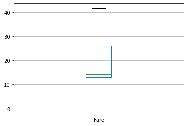

```python
pclass2.boxplot(column=['Fare'])
```

## pclass 3

```python
iqrp3=pclass3['Fare'].quantile(0.75)-pclass3['Fare'].quantile(0.25)
print(iqrp3)
```

```
7.75
```

```python
Upper_OutlierLimit3 = pclass3['Fare'].quantile(0.75) + 1.5*iqrp3
Lower_OutlierLimit3 = pclass3['Fare'].quantile(0.25) - 1.5*iqrp3
print(Upper_OutlierLimit3)
print(Lower_OutlierLimit3)
```

```
27.125
-3.875
```

```python
OutlierValues3 = pclass3[(pclass3['Fare']>=Upper_OutlierLimit3) | (pclass3['Fare']<=Lower_OutlierLimit3)]
OutlierValues3
```

|  | Survived | Pclass | Sex | Age | SibSp | Parch | Fare | Embarked |
| --- | --- | --- | --- | --- | --- | --- | --- | --- |
| 13 | 0 | 3 | male | 39.0 | 1 | 5 | 31.2750 | S |
| 16 | 0 | 3 | male | 6.0 | 4 | 1 | 29.1250 | Q |
| 25 | 1 | 3 | female | 38.0 | 1 | 5 | 31.3875 | S |
| 50 | 0 | 3 | male | 7.0 | 4 | 1 | 39.6875 | S |
| 59 | 0 | 3 | male | 11.0 | 5 | 2 | 46.9000 | S |
| 63 | 0 | 3 | male | 4.0 | 3 | 2 | 27.9000 | S |
| 71 | 0 | 3 | female | 16.0 | 5 | 2 | 46.9000 | S |
| 74 | 1 | 3 | male | 32.0 | 0 | 0 | 56.4958 | S |
| 86 | 0 | 3 | male | 16.0 | 1 | 3 | 34.3750 | S |
| 119 | 0 | 3 | female | 6.0 | 4 | 2 | 31.2750 | S |
| 147 | 0 | 3 | female | 9.0 | 2 | 2 | 34.3750 | S |
| 159 | 0 | 3 | male | 28.0 | 8 | 2 | 69.5500 | S |
| 164 | 0 | 3 | male | 6.0 | 4 | 1 | 39.6875 | S |
| 167 | 0 | 3 | female | 45.0 | 1 | 4 | 27.9000 | S |
| 169 | 0 | 3 | male | 28.0 | 0 | 0 | 56.4958 | S |
| 171 | 0 | 3 | male | 4.0 | 4 | 1 | 29.1250 | Q |
| 180 | 0 | 3 | female | 28.0 | 8 | 2 | 69.5500 | S |
| 182 | 0 | 3 | male | 9.0 | 4 | 2 | 31.3875 | S |
| 201 | 0 | 3 | male | 28.0 | 8 | 2 | 69.5500 | S |
| 233 | 1 | 3 | female | 5.0 | 4 | 2 | 31.3875 | S |
| 261 | 1 | 3 | male | 3.0 | 4 | 2 | 31.3875 | S |
| 266 | 0 | 3 | male | 16.0 | 4 | 1 | 39.6875 | S |
| 278 | 0 | 3 | male | 7.0 | 4 | 1 | 29.1250 | Q |
| 324 | 0 | 3 | male | 28.0 | 8 | 2 | 69.5500 | S |
| 360 | 0 | 3 | male | 40.0 | 1 | 4 | 27.9000 | S |
| 386 | 0 | 3 | male | 6.0 | 5 | 2 | 46.9000 | S |
| 436 | 0 | 3 | female | 21.0 | 2 | 2 | 34.3750 | S |
| 480 | 0 | 3 | male | 9.0 | 5 | 2 | 46.9000 | S |
| 509 | 1 | 3 | male | 26.0 | 0 | 0 | 56.4958 | S |
| 541 | 0 | 3 | female | 9.0 | 4 | 2 | 31.2750 | S |
| 542 | 0 | 3 | female | 11.0 | 4 | 2 | 31.2750 | S |
| 610 | 0 | 3 | female | 39.0 | 1 | 5 | 31.2750 | S |
| 634 | 0 | 3 | female | 9.0 | 3 | 2 | 27.9000 | S |
| 638 | 0 | 3 | female | 41.0 | 0 | 5 | 39.6875 | S |
| 642 | 0 | 3 | female | 6.0 | 3 | 2 | 27.9000 | S |
| 643 | 1 | 3 | male | 28.0 | 0 | 0 | 56.4958 | S |
| 678 | 0 | 3 | female | 43.0 | 1 | 6 | 46.9000 | S |
| 683 | 0 | 3 | male | 14.0 | 5 | 2 | 46.9000 | S |
| 686 | 0 | 3 | male | 14.0 | 4 | 1 | 39.6875 | S |
| 692 | 1 | 3 | male | 28.0 | 0 | 0 | 56.4958 | S |
| 736 | 0 | 3 | female | 48.0 | 1 | 3 | 34.3750 | S |
| 787 | 0 | 3 | male | 8.0 | 4 | 1 | 29.1250 | Q |
| 792 | 0 | 3 | female | 28.0 | 8 | 2 | 69.5500 | S |
| 813 | 0 | 3 | female | 6.0 | 4 | 2 | 31.2750 | S |
| 819 | 0 | 3 | male | 10.0 | 3 | 2 | 27.9000 | S |
| 824 | 0 | 3 | male | 6.0 | 4 | 1 | 39.6875 | S |
| 826 | 0 | 3 | male | 28.0 | 0 | 0 | 56.4958 | S |
| 838 | 1 | 3 | male | 32.0 | 0 | 0 | 56.4958 | S |
| 846 | 0 | 3 | male | 28.0 | 8 | 2 | 69.5500 | S |
| 850 | 0 | 3 | male | 4.0 | 4 | 2 | 31.2750 | S |
| 863 | 0 | 3 | female | 28.0 | 8 | 2 | 69.5500 | S |
| 885 | 0 | 3 | female | 39.0 | 0 | 5 | 29.1250 | Q |

```python
OutlierValues3.info()
```

```
<class 'pandas.core.frame.DataFrame'>
Int64Index: 52 entries, 13 to 885
Data columns (total 8 columns):
 #   Column    Non-Null Count  Dtype
---  ------    --------------  -----
 0   Survived  52 non-null     int64
 1   Pclass    52 non-null     int64
 2   Sex       52 non-null     object
 3   Age       52 non-null     float64
 4   SibSp     52 non-null     int64
 5   Parch     52 non-null     int64
 6   Fare      52 non-null     float64
 7   Embarked  52 non-null     object
dtypes: float64(2), int64(4), object(2)
memory usage: 3.2+ KB
```

```python
pclass3['Fare'][(pclass3['Fare']>Upper_OutlierLimit3)]=pclass3['Fare'].quantile(0.85)
```

[output not shown]

```python
pclass3[pclass3['Fare']>Upper_OutlierLimit3]
```

|  | Survived | Pclass | Sex | Age | SibSp | Parch | Fare | Embarked |
| --- | --- | --- | --- | --- | --- | --- | --- | --- |

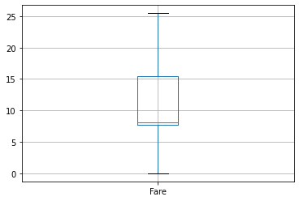

```python
pclass3.boxplot(column=['Fare'])
```

### Concatenating

```python
data=pd.concat([pclass1,pclass2,pclass3],join='outer',ignore_index=False)
```

```python
data.info()
```

```
<class 'pandas.core.frame.DataFrame'>
Int64Index: 891 entries, 1 to 890
Data columns (total 8 columns):
 #   Column    Non-Null Count  Dtype
---  ------    --------------  -----
 0   Survived  891 non-null    int64
 1   Pclass    891 non-null    int64
 2   Sex       891 non-null    object
 3   Age       891 non-null    float64
 4   SibSp     891 non-null    int64
 5   Parch     891 non-null    int64
 6   Fare      891 non-null    float64
 7   Embarked  891 non-null    object
dtypes: float64(2), int64(4), object(2)
memory usage: 55.7+ KB
```

```python
data
```

|  | Survived | Pclass | Sex | Age | SibSp | Parch | Fare | Embarked |
| --- | --- | --- | --- | --- | --- | --- | --- | --- |
| 1 | 1 | 1 | female | 38.0 | 1 | 0 | 71.2833 | C |
| 3 | 1 | 1 | female | 35.0 | 1 | 0 | 53.1000 | S |
| 6 | 0 | 1 | male | 54.0 | 0 | 0 | 51.8625 | S |
| 11 | 1 | 1 | female | 54.0 | 0 | 0 | 26.5500 | S |
| 23 | 1 | 1 | male | 28.0 | 0 | 0 | 35.5000 | S |
| ... | ... | ... | ... | ... | ... | ... | ... | ... |
| 882 | 0 | 3 | female | 22.0 | 0 | 0 | 10.5167 | S |
| 884 | 0 | 3 | male | 25.0 | 0 | 0 | 7.0500 | S |
| 885 | 0 | 3 | female | 39.0 | 0 | 5 | 21.0750 | Q |
| 888 | 0 | 3 | female | 28.0 | 1 | 2 | 23.4500 | S |
| 890 | 0 | 3 | male | 32.0 | 0 | 0 | 7.7500 | Q |

891 rows × 8 columns

## Feature Engineering

```python
obj = data.dtypes == np.object
```

```python
obj
```

```
Survived    False
Pclass      False
Sex          True
Age         False
SibSp       False
Parch       False
Fare        False
Embarked     True
dtype: bool
```

```python
data.columns[obj]
```

```
Index(['Sex', 'Embarked'], dtype='object')
```

```python
dummydf=pd.DataFrame()
for i in data.columns[obj]:
    dummy=pd.get_dummies(data[i],drop_first=True)
    dummydf=pd.concat([dummydf,dummy],axis=1)
print(dummydf)
```

```
     male  Q  S
1       0  0  0
3       0  0  1
6       1  0  1
11      0  0  1
23      1  0  1
..    ... .. ..
882     0  0  1
884     1  0  1
885     0  1  0
888     0  0  1
890     1  1  0

[891 rows x 3 columns]
```

```python
data1=pd.concat([data,dummydf],axis=1)
```

```python
data1
```

|  | Survived | Pclass | Sex | Age | SibSp | Parch | Fare | Embarked | male | Q | S |
| --- | --- | --- | --- | --- | --- | --- | --- | --- | --- | --- | --- |
| 1 | 1 | 1 | female | 38.0 | 1 | 0 | 71.2833 | C | 0 | 0 | 0 |
| 3 | 1 | 1 | female | 35.0 | 1 | 0 | 53.1000 | S | 0 | 0 | 1 |
| 6 | 0 | 1 | male | 54.0 | 0 | 0 | 51.8625 | S | 1 | 0 | 1 |
| 11 | 1 | 1 | female | 54.0 | 0 | 0 | 26.5500 | S | 0 | 0 | 1 |
| 23 | 1 | 1 | male | 28.0 | 0 | 0 | 35.5000 | S | 1 | 0 | 1 |
| ... | ... | ... | ... | ... | ... | ... | ... | ... | ... | ... | ... |
| 882 | 0 | 3 | female | 22.0 | 0 | 0 | 10.5167 | S | 0 | 0 | 1 |
| 884 | 0 | 3 | male | 25.0 | 0 | 0 | 7.0500 | S | 1 | 0 | 1 |
| 885 | 0 | 3 | female | 39.0 | 0 | 5 | 21.0750 | Q | 0 | 1 | 0 |
| 888 | 0 | 3 | female | 28.0 | 1 | 2 | 23.4500 | S | 0 | 0 | 1 |
| 890 | 0 | 3 | male | 32.0 | 0 | 0 | 7.7500 | Q | 1 | 1 | 0 |

891 rows × 11 columns

```python
data1.drop(['Sex','Embarked'],axis=1,inplace=True)
```

```python
data1
```

|  | Survived | Pclass | Age | SibSp | Parch | Fare | male | Q | S |
| --- | --- | --- | --- | --- | --- | --- | --- | --- | --- |
| 1 | 1 | 1 | 38.0 | 1 | 0 | 71.2833 | 0 | 0 | 0 |
| 3 | 1 | 1 | 35.0 | 1 | 0 | 53.1000 | 0 | 0 | 1 |
| 6 | 0 | 1 | 54.0 | 0 | 0 | 51.8625 | 1 | 0 | 1 |
| 11 | 1 | 1 | 54.0 | 0 | 0 | 26.5500 | 0 | 0 | 1 |
| 23 | 1 | 1 | 28.0 | 0 | 0 | 35.5000 | 1 | 0 | 1 |
| ... | ... | ... | ... | ... | ... | ... | ... | ... | ... |
| 882 | 0 | 3 | 22.0 | 0 | 0 | 10.5167 | 0 | 0 | 1 |
| 884 | 0 | 3 | 25.0 | 0 | 0 | 7.0500 | 1 | 0 | 1 |
| 885 | 0 | 3 | 39.0 | 0 | 5 | 21.0750 | 0 | 1 | 0 |
| 888 | 0 | 3 | 28.0 | 1 | 2 | 23.4500 | 0 | 0 | 1 |
| 890 | 0 | 3 | 32.0 | 0 | 0 | 7.7500 | 1 | 1 | 0 |

891 rows × 9 columns

```python
data2=pd.get_dummies(data,drop_first=True)
```

```python
data2
```

|  | Survived | Pclass | Age | SibSp | Parch | Fare | Sex_male | Embarked_Q | Embarked_S |
| --- | --- | --- | --- | --- | --- | --- | --- | --- | --- |
| 1 | 1 | 1 | 38.0 | 1 | 0 | 71.2833 | 0 | 0 | 0 |
| 3 | 1 | 1 | 35.0 | 1 | 0 | 53.1000 | 0 | 0 | 1 |
| 6 | 0 | 1 | 54.0 | 0 | 0 | 51.8625 | 1 | 0 | 1 |
| 11 | 1 | 1 | 54.0 | 0 | 0 | 26.5500 | 0 | 0 | 1 |
| 23 | 1 | 1 | 28.0 | 0 | 0 | 35.5000 | 1 | 0 | 1 |
| ... | ... | ... | ... | ... | ... | ... | ... | ... | ... |
| 882 | 0 | 3 | 22.0 | 0 | 0 | 10.5167 | 0 | 0 | 1 |
| 884 | 0 | 3 | 25.0 | 0 | 0 | 7.0500 | 1 | 0 | 1 |
| 885 | 0 | 3 | 39.0 | 0 | 5 | 21.0750 | 0 | 1 | 0 |
| 888 | 0 | 3 | 28.0 | 1 | 2 | 23.4500 | 0 | 0 | 1 |
| 890 | 0 | 3 | 32.0 | 0 | 0 | 7.7500 | 1 | 1 | 0 |

891 rows × 9 columns

```python
cols=['Pclass','Age','SibSp','Parch','Fare','male','Q','S','Survived']
data1=data1[cols]
data1
```

|  | Pclass | Age | SibSp | Parch | Fare | male | Q | S | Survived |
| --- | --- | --- | --- | --- | --- | --- | --- | --- | --- |
| 1 | 1 | 38.0 | 1 | 0 | 71.2833 | 0 | 0 | 0 | 1 |
| 3 | 1 | 35.0 | 1 | 0 | 53.1000 | 0 | 0 | 1 | 1 |
| 6 | 1 | 54.0 | 0 | 0 | 51.8625 | 1 | 0 | 1 | 0 |
| 11 | 1 | 54.0 | 0 | 0 | 26.5500 | 0 | 0 | 1 | 1 |
| 23 | 1 | 28.0 | 0 | 0 | 35.5000 | 1 | 0 | 1 | 1 |
| ... | ... | ... | ... | ... | ... | ... | ... | ... | ... |
| 882 | 3 | 22.0 | 0 | 0 | 10.5167 | 0 | 0 | 1 | 0 |
| 884 | 3 | 25.0 | 0 | 0 | 7.0500 | 1 | 0 | 1 | 0 |
| 885 | 3 | 39.0 | 0 | 5 | 21.0750 | 0 | 1 | 0 | 0 |
| 888 | 3 | 28.0 | 1 | 2 | 23.4500 | 0 | 0 | 1 | 0 |
| 890 | 3 | 32.0 | 0 | 0 | 7.7500 | 1 | 1 | 0 | 0 |

891 rows × 9 columns

```python
data1.shape
```

```
(891, 9)
```

```python
data1.info()
```

```
<class 'pandas.core.frame.DataFrame'>
Int64Index: 891 entries, 1 to 890
Data columns (total 9 columns):
 #   Column    Non-Null Count  Dtype
---  ------    --------------  -----
 0   Pclass    891 non-null    int64
 1   Age       891 non-null    float64
 2   SibSp     891 non-null    int64
 3   Parch     891 non-null    int64
 4   Fare      891 non-null    float64
 5   male      891 non-null    uint8
 6   Q         891 non-null    uint8
 7   S         891 non-null    uint8
 8   Survived  891 non-null    int64
dtypes: float64(2), int64(4), uint8(3)
memory usage: 51.3 KB
```

```python
data1.describe()
```

|  | Pclass | Age | SibSp | Parch | Fare | male | Q | S | Survived |
| --- | --- | --- | --- | --- | --- | --- | --- | --- | --- |
| count | 891.000000 | 891.000000 | 891.000000 | 891.000000 | 891.000000 | 891.000000 | 891.000000 | 891.000000 | 891.000000 |
| mean | 2.308642 | 29.109989 | 0.523008 | 0.381594 | 28.037005 | 0.647587 | 0.086420 | 0.725028 | 0.383838 |
| std | 0.836071 | 11.826281 | 1.102743 | 0.806057 | 34.593345 | 0.477990 | 0.281141 | 0.446751 | 0.486592 |
| min | 1.000000 | 3.000000 | 0.000000 | 0.000000 | 0.000000 | 0.000000 | 0.000000 | 0.000000 | 0.000000 |
| 25% | 2.000000 | 22.000000 | 0.000000 | 0.000000 | 7.910400 | 0.000000 | 0.000000 | 0.000000 | 0.000000 |
| 50% | 3.000000 | 28.000000 | 0.000000 | 0.000000 | 14.454200 | 1.000000 | 0.000000 | 1.000000 | 0.000000 |
| 75% | 3.000000 | 35.000000 | 1.000000 | 0.000000 | 26.550000 | 1.000000 | 0.000000 | 1.000000 | 1.000000 |
| max | 3.000000 | 54.000000 | 8.000000 | 6.000000 | 164.866700 | 1.000000 | 1.000000 | 1.000000 | 1.000000 |

## LOGISTIC REGRESSION

#### Defining x and y

```python
x=data1.iloc[:,:-1].values
y=data1.iloc[:,-1].values
```

```python
x.shape
```

```
(891, 8)
```

```python
y.shape
```

```
(891,)
```

### Splitting the dataset

```python
from sklearn.model_selection import train_test_split
xtrain,xtest,ytrain,ytest=train_test_split(x,y,test_size=0.2,random_state=0)
```

### scaling

```python
from sklearn.preprocessing import StandardScaler
scx=StandardScaler()
xtrain=scx.fit_transform(xtrain)
xtest=scx.fit_transform(xtest)
```

```python
from sklearn.linear_model import LogisticRegression
lr = LogisticRegression()

# fit the model to the training data
lr.fit(xtrain, ytrain)
```

```
LogisticRegression()
```

```python
ypred=lr.predict(xtest)
```

```python
ytest
```

```
array([0, 0, 0, 0, 0, 1, 0, 1, 0, 0, 1, 0, 0, 1, 1, 0, 0, 0, 1, 0, 1, 0,
       0, 1, 0, 0, 1, 1, 0, 0, 1, 0, 0, 0, 0, 0, 0, 0, 1, 1, 1, 0, 0, 0,
       1, 0, 0, 1, 0, 0, 0, 0, 0, 0, 1, 0, 1, 0, 0, 0, 0, 0, 1, 0, 0, 0,
       1, 0, 1, 0, 0, 0, 0, 0, 0, 0, 0, 1, 1, 0, 0, 1, 1, 0, 1, 0, 0, 0,
       1, 0, 0, 0, 0, 0, 1, 1, 0, 0, 0, 0, 0, 1, 1, 1, 0, 0, 0, 0, 0, 0,
       0, 1, 0, 1, 0, 0, 1, 0, 1, 1, 0, 0, 0, 0, 0, 0, 1, 0, 1, 0, 0, 0,
       1, 0, 0, 1, 1, 1, 0, 0, 1, 1, 0, 1, 0, 0, 0, 0, 0, 0, 1, 0, 0, 1,
       0, 1, 1, 1, 1, 1, 0, 0, 0, 1, 0, 0, 0, 1, 1, 0, 0, 1, 0, 0, 1, 0,
       1, 0, 0], dtype=int64)
```

```python
ypred
```

```
array([0, 0, 1, 1, 0, 1, 0, 1, 0, 0, 0, 0, 0, 1, 1, 0, 0, 1, 1, 0, 0, 0,
       0, 1, 0, 0, 1, 1, 0, 0, 0, 0, 0, 1, 0, 0, 0, 0, 1, 1, 1, 0, 0, 0,
       1, 1, 0, 1, 0, 0, 1, 0, 0, 0, 0, 0, 0, 0, 0, 0, 1, 0, 1, 0, 1, 0,
       1, 0, 0, 0, 0, 0, 1, 1, 0, 1, 1, 1, 1, 0, 0, 1, 1, 1, 1, 0, 0, 0,
       1, 0, 0, 0, 1, 0, 0, 1, 0, 0, 0, 1, 0, 0, 0, 0, 0, 0, 0, 0, 0, 0,
       0, 0, 1, 0, 0, 1, 0, 0, 1, 0, 0, 1, 0, 0, 0, 1, 1, 0, 1, 0, 0, 0,
       1, 0, 1, 1, 1, 1, 0, 0, 1, 1, 0, 0, 0, 0, 0, 0, 0, 0, 1, 0, 0, 1,
       0, 0, 1, 0, 1, 0, 0, 1, 0, 1, 0, 1, 0, 1, 1, 0, 1, 1, 0, 0, 1, 0,
       1, 0, 0], dtype=int64)
```

## Model Evaluation Using Confusion Matrix

```python
from sklearn.metrics import confusion_matrix
confusion = confusion_matrix(ytest, ypred)
print(confusion)
```

```
[[97 23]
 [18 41]]
```

```python
confusion_matrix = pd.DataFrame(confusion)
confusion_matrix.columns = ['Predicted No Subscription', 'Predicted Yes Subscription']
confusion_matrix = confusion_matrix.rename(index = {0 : 'Actual No Subscription', 1 : 'Actual Yes Subscription'})
confusion_matrix
```

[output not shown]

```python
TN = confusion [0,0]
FP = confusion [0,1]
FN = confusion [1,0]
TP = confusion [1,1]
```

### Accuracy

```python
from sklearn import metrics
accuracy = metrics.accuracy_score(ytest, ypred)
print('accuracy' ,accuracy)
print ('classificaton error ',round(1-metrics.accuracy_score(ytest, ypred),4))
```

```
accuracy 0.770949720670391
classificaton error  0.2291
```

## sensitivity or recall

```python
print ("RECALL:", metrics.recall_score(ytest,ypred))
```

```
RECALL: 0.6949152542372882
```

## specificity

```python
print ("SPECIFICITY/TRUE NEGATIVE RATE:", (TN)/(TN+FP))
```

```
SPECIFICITY/TRUE NEGATIVE RATE: 0.8083333333333333
```

```python
print("FALSE POSITIVE RATE: ",(FN)/(FN+TP))
```

[output not shown]

```python
print("FALSE NEGATIVE RATE: ",(FP)/(TN+FP))
```

[output not shown]

## Precision

```python
print ("Precision: ", round(metrics.precision_score(ytest,ypred),2))
print ("PRECISION CALCULATED: ", round(TP/float(TP+FP),2))
```

```
Precision:  0.64
PRECISION CALCULATED:  0.64
```

```python
from sklearn.metrics import accuracy_score,f1_score,precision_score,recall_score,roc_auc_score
accuracy = accuracy_score(ytest, ypred)
recall = recall_score(ytest, ypred)
precision = precision_score(ytest, ypred)
f1 = f1_score(ytest, ypred)
roc_auc = roc_auc_score(ytest, ypred)

print('Accuracy is  :' ,round(accuracy,2)*100)
print('F1 score is :' ,round(f1,2)*100)
print('Precision is  :',round(precision,2)*100)
print('Recall is  :',round(recall,4)*100)
print('Roc Auc is  :',round(roc_auc,2)*100)
```

```
Accuracy is  : 77.0
F1 score is : 67.0
Precision is  : 64.0
Recall is  : 69.49
Roc Auc is  : 75.0
```

```python
from sklearn.metrics import classification_report
print(classification_report(ytest, ypred))
```

```
              precision    recall  f1-score   support

           0       0.84      0.81      0.83       120
           1       0.64      0.69      0.67        59

    accuracy                           0.77       179
   macro avg       0.74      0.75      0.75       179
weighted avg       0.78      0.77      0.77       179
```

## Accuracy is 77%

# KNN

```python
from sklearn.model_selection import train_test_split
xtrain, xtest, ytrain, ytest = train_test_split(x, y, test_size=0.3, random_state=0)
```

```python
print(xtrain.shape)
print(ytrain.shape)
print(xtest.shape)
print(ytest.shape)
```

```
(623, 8)
(623,)
(268, 8)
(268,)
```

```python
from sklearn.preprocessing import StandardScaler
sc_X = StandardScaler()
xtrain = sc_X.fit_transform(xtrain)
xtest = sc_X.transform(xtest)
```

```python
np.set_printoptions(suppress=True)
```

```python
xtrain
```

```
array([[ 0.81831314, -0.08099495, -0.47638226, ...,  0.7702924 ,
        -0.30177525, -1.62581514],
       [-1.55289191,  2.09472014, -0.47638226, ..., -1.29820831,
        -0.30177525,  0.61507608],
       [-0.36728938,  0.1700491 ,  0.37400785, ...,  0.7702924 ,
        -0.30177525, -1.62581514],
       ...,
       [ 0.81831314,  1.84367609, -0.47638226, ...,  0.7702924 ,
        -0.30177525,  0.61507608],
       [ 0.81831314, -0.332039  ,  0.37400785, ...,  0.7702924 ,
        -0.30177525,  0.61507608],
       [ 0.81831314, -0.24835765, -0.47638226, ...,  0.7702924 ,
        -0.30177525,  0.61507608]])
```

```python
from sklearn.neighbors import KNeighborsClassifier
knn = KNeighborsClassifier()
knn.fit(xtrain,ytrain)
```

```
KNeighborsClassifier()
```

```python
ypred=knn.predict(xtest)
```

```python
from sklearn.metrics import confusion_matrix, accuracy_score, classification_report
confusion_matrix(ytest, ypred)
```

```
array([[147,  30],
       [ 26,  65]], dtype=int64)
```

```python
ytest
```

```
array([0, 0, 0, 0, 0, 1, 0, 1, 0, 0, 1, 0, 0, 1, 1, 0, 0, 0, 1, 0, 1, 0,
       0, 1, 0, 0, 1, 1, 0, 0, 1, 0, 0, 0, 0, 0, 0, 0, 1, 1, 1, 0, 0, 0,
       1, 0, 0, 1, 0, 0, 0, 0, 0, 0, 1, 0, 1, 0, 0, 0, 0, 0, 1, 0, 0, 0,
       1, 0, 1, 0, 0, 0, 0, 0, 0, 0, 0, 1, 1, 0, 0, 1, 1, 0, 1, 0, 0, 0,
       1, 0, 0, 0, 0, 0, 1, 1, 0, 0, 0, 0, 0, 1, 1, 1, 0, 0, 0, 0, 0, 0,
       0, 1, 0, 1, 0, 0, 1, 0, 1, 1, 0, 0, 0, 0, 0, 0, 1, 0, 1, 0, 0, 0,
       1, 0, 0, 1, 1, 1, 0, 0, 1, 1, 0, 1, 0, 0, 0, 0, 0, 0, 1, 0, 0, 1,
       0, 1, 1, 1, 1, 1, 0, 0, 0, 1, 0, 0, 0, 1, 1, 0, 0, 1, 0, 0, 1, 0,
       1, 0, 0, 0, 0, 0, 0, 1, 1, 0, 0, 0, 0, 0, 0, 0, 0, 0, 0, 0, 1, 1,
       0, 0, 1, 0, 1, 1, 1, 1, 0, 0, 1, 0, 0, 0, 0, 0, 0, 0, 1, 0, 0, 1,
       1, 1, 1, 1, 1, 0, 0, 1, 0, 0, 0, 0, 0, 0, 1, 0, 0, 1, 1, 0, 1, 0,
       0, 1, 0, 1, 0, 1, 0, 0, 0, 0, 0, 1, 1, 1, 0, 0, 0, 1, 1, 1, 0, 0,
       0, 0, 0, 1], dtype=int64)
```

```python
ypred
```

```
array([0, 0, 1, 1, 0, 1, 0, 1, 0, 0, 0, 0, 1, 0, 1, 0, 0, 0, 1, 0, 0, 0,
       0, 1, 0, 0, 0, 1, 0, 0, 1, 0, 1, 1, 0, 0, 0, 0, 1, 1, 1, 0, 0, 0,
       1, 1, 0, 1, 0, 0, 0, 1, 0, 0, 0, 0, 1, 0, 0, 0, 1, 0, 1, 0, 1, 0,
       1, 0, 0, 0, 0, 0, 1, 0, 0, 1, 1, 1, 1, 1, 0, 0, 1, 1, 1, 0, 0, 0,
       1, 0, 0, 0, 1, 0, 0, 1, 0, 0, 0, 1, 1, 1, 0, 0, 0, 0, 0, 0, 0, 0,
       0, 0, 1, 1, 0, 0, 0, 0, 1, 0, 0, 1, 0, 0, 0, 1, 1, 0, 1, 0, 0, 0,
       1, 0, 1, 1, 1, 1, 0, 0, 1, 1, 0, 0, 0, 0, 0, 0, 0, 0, 1, 0, 0, 1,
       0, 0, 1, 0, 1, 0, 0, 1, 0, 1, 0, 1, 0, 1, 1, 0, 1, 1, 0, 0, 1, 0,
       1, 0, 0, 1, 0, 0, 1, 0, 1, 0, 0, 0, 0, 0, 0, 0, 0, 0, 0, 1, 1, 1,
       0, 0, 1, 0, 0, 1, 1, 1, 0, 0, 0, 0, 0, 0, 0, 0, 0, 0, 1, 0, 0, 1,
       1, 0, 1, 0, 1, 1, 0, 0, 0, 0, 0, 0, 0, 0, 0, 0, 0, 0, 1, 0, 1, 0,
       0, 1, 0, 1, 1, 0, 0, 0, 0, 0, 0, 1, 1, 1, 0, 0, 0, 1, 1, 1, 0, 0,
       0, 0, 1, 1], dtype=int64)
```

```python
accuracy_score(ytest, ypred)
```

```
0.7910447761194029
```

```python
error = []
accuracy = []


for i in range(1,40,2):
    knn = KNeighborsClassifier(n_neighbors=i)
    knn.fit(xtrain, ytrain)
    pred_i = knn.predict(xtest)
    error.append(np.mean(pred_i != ytest))
    accuracy.append(accuracy_score(ytest, pred_i))
```

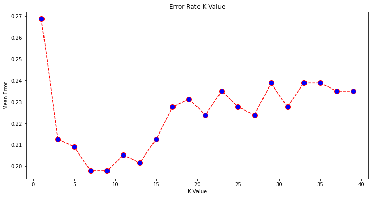

```python
plt.figure(figsize=(12, 6))
plt.plot(range(1,40,2), error, color='red', linestyle='dashed', marker='o',
         markerfacecolor='blue', markersize=10)
plt.title('Error Rate K Value')
plt.xlabel('K Value')
plt.ylabel('Mean Error')
```

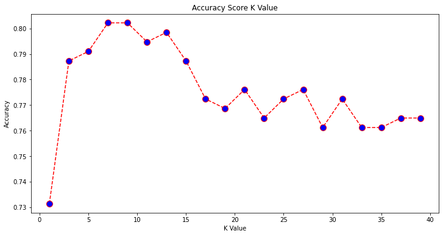

```python
plt.figure(figsize=(12, 6))
plt.plot(range(1,40,2), accuracy, color='red', linestyle='dashed', marker='o',
         markerfacecolor='blue', markersize=10)
plt.title('Accuracy Score K Value')
plt.xlabel('K Value')
plt.ylabel('Accuracy')
```

```python
from sklearn.neighbors import KNeighborsClassifier
knn = KNeighborsClassifier(n_neighbors=9)
```

```python
knn.fit(xtrain,ytrain)
```

```
KNeighborsClassifier(n_neighbors=9)
```

```python
ypred1=knn.predict(xtest)
```

```python
from sklearn.metrics import confusion_matrix, accuracy_score, classification_report
confusion_matrix(ytest, ypred1)
```

```
array([[151,  26],
       [ 27,  64]], dtype=int64)
```

```python
accuracy_score(ytest, ypred1)
```

```
0.8022388059701493
```

```python
print(classification_report(ytest, ypred1))
```

```
              precision    recall  f1-score   support

           0       0.85      0.85      0.85       177
           1       0.71      0.70      0.71        91

    accuracy                           0.80       268
   macro avg       0.78      0.78      0.78       268
weighted avg       0.80      0.80      0.80       268
```